# R Notebook

```r
library(tidyverse)
data(msleep)
```

```r
library(infer)
```

```r
view(msleep)
```

Jabberwockies sleep for around 7 hours a night, on average. Perform an appropriate statistical test to determine whether the mean sleep_total in the sampled population of animal types differs from the typical value for jabberwockies.

Null hypothesis: The mean sleep_total of sampled animal types does not differ from the mean sleep value of jabberwockies. H(0): μ(sleep_total) = 7

Alternative hypothesis: The mean sleep_total of sampled animals types differs from the mean sleep value of jabberwockies. H(a): μ(sleep_total) != 7

α = 0.05

```r
observed_stat <- msleep %>%
  summarise(mean_sleep = mean(sleep_total))
observed_stat
```

| mean_sleep |
| --- |
| 10.43373 |

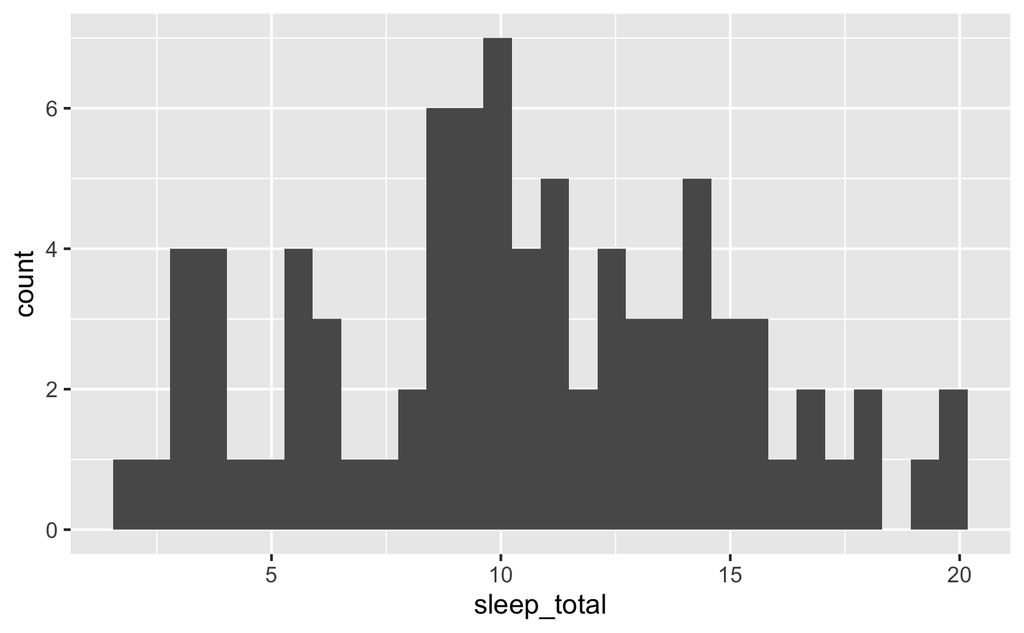

```r
msleep %>%
ggplot(aes(x = sleep_total)) +
geom_histogram(bins = 30)
```

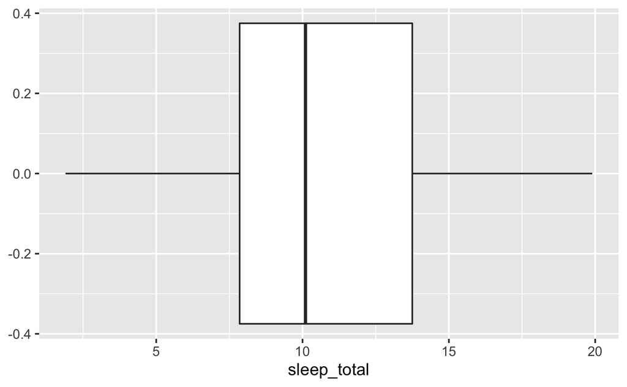

```r
msleep %>%
ggplot(aes(y = sleep_total)) +
  geom_boxplot() +
  coord_flip()
```

```r
NA
```

```r
null_distribution <- msleep %>%
  specify(response = sleep_total) %>%
  hypothesize(null = "point", mu = 7) %>%
  generate(reps = 10000, type = "bootstrap") %>%
  calculate(stat = "mean")

null_distribution
```

| replicate | stat |
| --- | --- |
| 1 | 7.536145 |
| 2 | 6.951807 |
| 3 | 6.380723 |
| 4 | 6.753012 |
| 5 | 7.465060 |
| 6 | 6.753012 |
| 7 | 7.106024 |
| 8 | 7.006024 |
| 9 | 6.886747 |
| 10 | 6.895181 |

[output cut: 990 more lines]

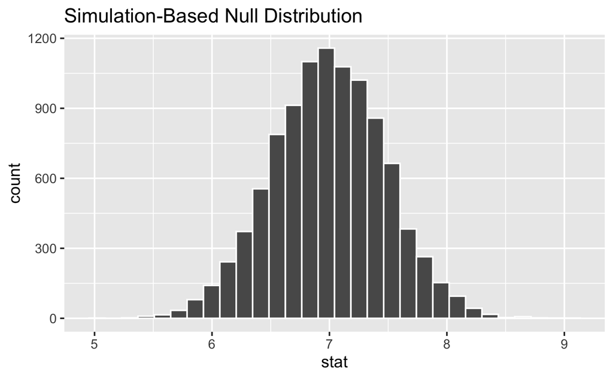

```r
null_distribution %>%
  visualise(bins = 30)
```

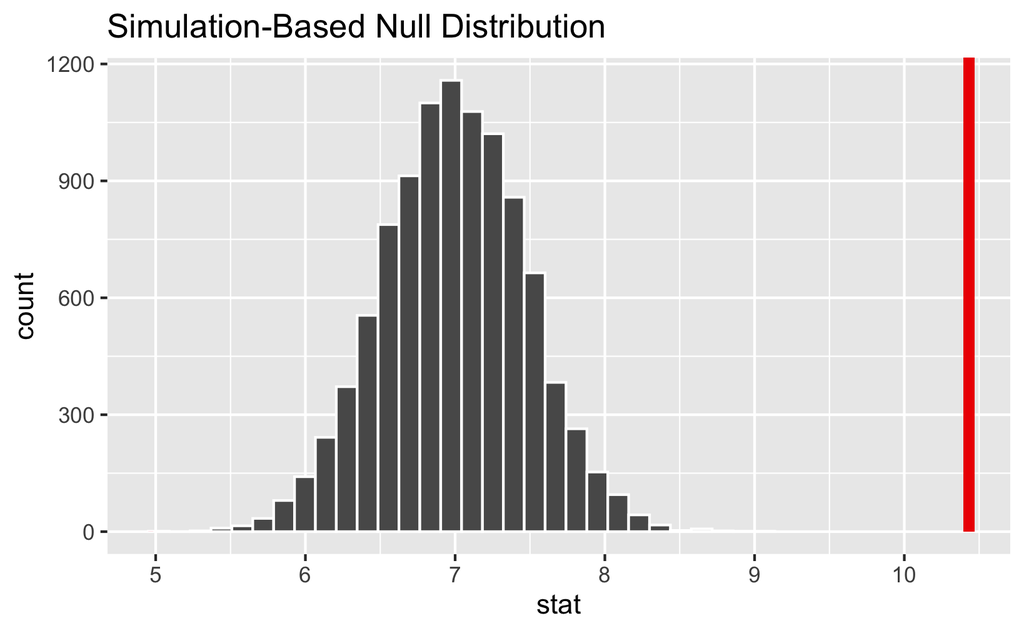

```r
null_distribution %>%
  visualise(bins = 30) +
  shade_p_value(obs_stat = observed_stat, direction = "both")
```

```r
p_value <- null_distribution %>%
  get_p_value(obs_stat = observed_stat, direction = "both")
p_value
```

| p_value |
| --- |
| 0 |

Reject the null hypothesis.

Perform an appropriate statistical test to determine whether omnivores sleep for significantly longer than herbivores, on average.

```r
msleep_tidy <- msleep %>%
  drop_na()
msleep_tidy
```

| name | genus | vore | order | conservation | sleep_total | sleep_rem | sleep_cycle | awake | brainwt | bodywt |
| --- | --- | --- | --- | --- | --- | --- | --- | --- | --- | --- |
| Greater short-tailed shrew | Blarina | omni | Soricomorpha | lc | 14.9 | 2.3 | 0.1333333 | 9.1 | 0.00029 | 0.019 |
| Cow | Bos | herbi | Artiodactyla | domesticated | 4.0 | 0.7 | 0.6666667 | 20.0 | 0.42300 | 600.000 |
| Dog | Canis | carni | Carnivora | domesticated | 10.1 | 2.9 | 0.3333333 | 13.9 | 0.07000 | 14.000 |
| Guinea pig | Cavis | herbi | Rodentia | domesticated | 9.4 | 0.8 | 0.2166667 | 14.6 | 0.00550 | 0.728 |
| Chinchilla | Chinchilla | herbi | Rodentia | domesticated | 12.5 | 1.5 | 0.1166667 | 11.5 | 0.00640 | 0.420 |
| Lesser short-tailed shrew | Cryptotis | omni | Soricomorpha | lc | 9.1 | 1.4 | 0.1500000 | 14.9 | 0.00014 | 0.005 |
| Long-nosed armadillo | Dasypus | carni | Cingulata | lc | 17.4 | 3.1 | 0.3833333 | 6.6 | 0.01080 | 3.500 |
| North American Opossum | Didelphis | omni | Didelphimorphia | lc | 18.0 | 4.9 | 0.3333333 | 6.0 | 0.00630 | 1.700 |
| Big brown bat | Eptesicus | insecti | Chiroptera | lc | 19.7 | 3.9 | 0.1166667 | 4.3 | 0.00030 | 0.023 |
| Horse | Equus | herbi | Perissodactyla | domesticated | 2.9 | 0.6 | 1.0000000 | 21.1 | 0.65500 | 521.000 |

[output cut: 10 more lines]

```r
omni_vs_herbi <- msleep_tidy %>%
  mutate(omni_herbi = case_when(vore == "omni" ~ "omni",
                                vore == "herbi" ~ "herbi")) %>%
  select(omni_herbi, sleep_total) %>%
drop_na()
omni_vs_herbi
```

| omni_herbi | sleep_total |
| --- | --- |
| omni | 14.9 |
| herbi | 4.0 |
| herbi | 9.4 |
| herbi | 12.5 |
| omni | 9.1 |
| omni | 18.0 |
| herbi | 2.9 |
| omni | 10.1 |
| herbi | 14.3 |
| herbi | 12.5 |

[output cut: 5 more lines]

```r
NA
```

null hypothesis: Omnivores do not sleep longer than herbivores. H(0): μ(sleep)omni - μ(sleep)herbi = 0

alternative hypothesis: Omnivores sleep longer than herbivores H(a): μ(sleep)omni - μ(sleep)herbi > 0

α = 0.05

```r
omni_vs_herbi %>%
  group_by(omni_herbi) %>%
  summarise(n = n())
```

| omni_herbi | n |
| --- | --- |
| herbi | 10 |
| omni | 5 |

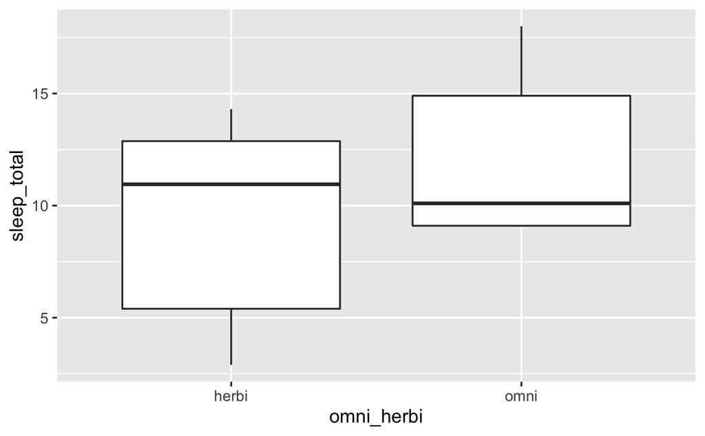

```r
omni_vs_herbi %>%
  ggplot(aes(y = sleep_total, x = omni_herbi)) +
  geom_boxplot()
```

```r
null_distribution_oh <- omni_vs_herbi %>%
  specify(sleep_total ~ omni_herbi) %>%
  hypothesize(null = "independence") %>%
  generate(reps = 10000, type = "permute") %>%
  calculate(stat = "diff in means", order = c("omni", "herbi"))
head(null_distribution_oh)
```

| replicate | stat |
| --- | --- |
| 1 | -0.76 |
| 2 | -0.67 |
| 3 | 3.83 |
| 4 | -2.29 |
| 5 | 2.24 |
| 6 | -2.80 |

```r
observed_stat <- omni_vs_herbi %>%
  specify(sleep_total ~ omni_herbi) %>%
  calculate(stat = "diff in means", order = c("omni", "herbi"))

observed_stat
```

| stat |
| --- |
| 2.72 |

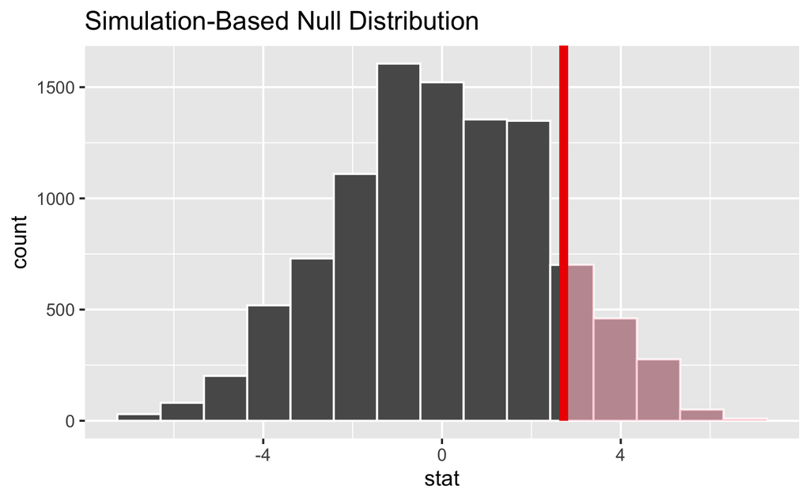

```r
null_distribution_oh %>%
  visualise() +
  shade_p_value(obs_stat = observed_stat, direction = "right")
```

```r
p_value <- null_distribution_oh %>%
  get_p_value(obs_stat = observed_stat, direction = "right")

p_value
```

| p_value |
| --- |
| 0.1294 |

Fail to reject the null hypothesis.

Perform an appropriate statistical test to determine whether the proportion of domesticated animals in the population of animal types is greater than 5%.

null hypothesis: the proportion of domesticated animals is not greater than 5% H(0) : p(domesticated) !> 0.05

alternative hypothesis: the proporition of domesticated animals is greater than 5 %. H(a) : p(domesticated) > 0.05

α=0.05

```r
domesticated_animals <- msleep %>%
  mutate(domesticated_flag = ifelse(conservation == "domesticated",
                                    "domesticated",
                                    "not_domesticated"))






domesticated_animals
```

| name | genus | vore | order | conservation | sleep_total | sleep_rem | sleep_cycle | awake | brainwt | bodywt | domesticated_flag |
| --- | --- | --- | --- | --- | --- | --- | --- | --- | --- | --- | --- |
| Cheetah | Acinonyx | carni | Carnivora | lc | 12.1 | NA | NA | 11.90 | NA | 50.000 | not_domesticated |
| Owl monkey | Aotus | omni | Primates | NA | 17.0 | 1.8 | NA | 7.00 | 0.01550 | 0.480 | NA |
| Mountain beaver | Aplodontia | herbi | Rodentia | nt | 14.4 | 2.4 | NA | 9.60 | NA | 1.350 | not_domesticated |
| Greater short-tailed shrew | Blarina | omni | Soricomorpha | lc | 14.9 | 2.3 | 0.1333333 | 9.10 | 0.00029 | 0.019 | not_domesticated |
| Cow | Bos | herbi | Artiodactyla | domesticated | 4.0 | 0.7 | 0.6666667 | 20.00 | 0.42300 | 600.000 | domesticated |
| Three-toed sloth | Bradypus | herbi | Pilosa | NA | 14.4 | 2.2 | 0.7666667 | 9.60 | NA | 3.850 | NA |
| Northern fur seal | Callorhinus | carni | Carnivora | vu | 8.7 | 1.4 | 0.3833333 | 15.30 | NA | 20.490 | not_domesticated |
| Vesper mouse | Calomys | NA | Rodentia | NA | 7.0 | NA | NA | 17.00 | NA | 0.045 | NA |
| Dog | Canis | carni | Carnivora | domesticated | 10.1 | 2.9 | 0.3333333 | 13.90 | 0.07000 | 14.000 | domesticated |
| Roe deer | Capreolus | herbi | Artiodactyla | lc | 3.0 | NA | NA | 21.00 | 0.09820 | 14.800 | not_domesticated |

[output cut: 73 more lines]

```r
NA
NA
```

```r
null_distribution_domesticated <- domesticated_animals %>%
  specify(response = domesticated_flag, success = "domesticated") %>%
  hypothesize(null = "point", p = 0.05) %>%
  generate(reps = 10000, type = "simulate") %>%
  calculate(stat = "prop")
```

```
Removed 29 rows containing missing values.
```

```r
head(null_distribution_domesticated)
```

| replicate | stat |
| --- | --- |
| 1 | 0.09259259 |
| 2 | 0.01851852 |
| 3 | 0.05555556 |
| 4 | 0.03703704 |
| 5 | 0.00000000 |
| 6 | 0.05555556 |

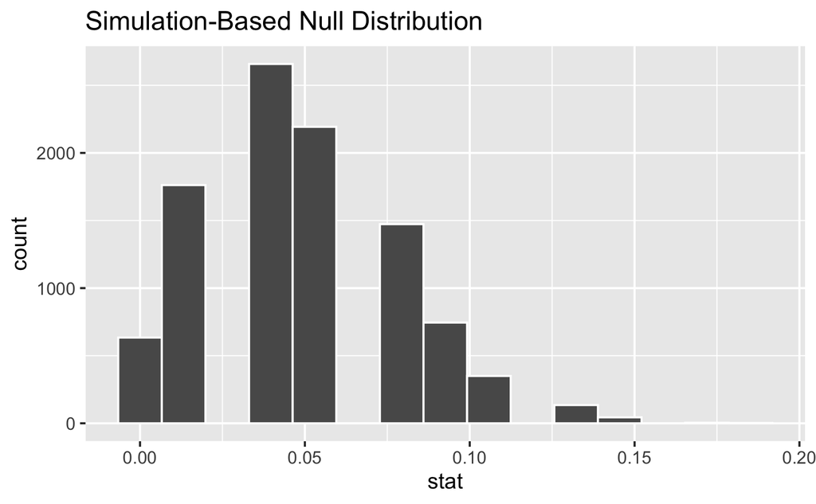

```r
null_distribution_domesticated %>%
  visualise()
```

```r
observed_stat_domesticated <- domesticated_animals %>%
  specify(response = domesticated_flag, success = "domesticated") %>%
  calculate(stat = "prop")
```

```
Removed 29 rows containing missing values.
```

```r
observed_stat
```

| stat |
| --- |
| 2.72 |

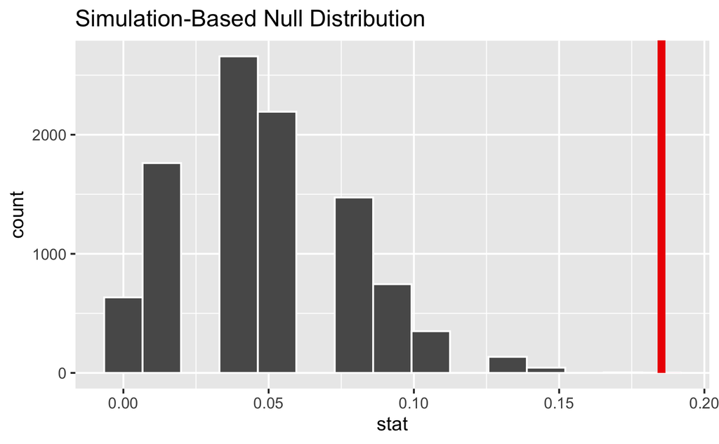

```r
null_distribution_domesticated %>%
  visualise() +
shade_p_value(obs_stat = observed_stat_domesticated, direction = "right")
```

```r
p_value <- null_distribution_domesticated %>%
  get_p_value(obs_stat = observed_stat_domesticated, direction = "right")

p_value
```

| p_value |
| --- |
| 2e-04 |

reject the null hypothesis.

I know something went wrong in this problem. I tried a few different ways to change the NAs, but I just couldn’t get it to work. Went ahead with the problem anyway, just to get the practice of working through it.